# Temperatura JP x CG

```r
climas = read_csv(here::here("data/clima_cg_jp-semanal.csv"),
                  col_types = "cTdddddd")
```

## Perguntas sobre Temperatura

```r
climas_qt = climas %>% dplyr::select(mes, tmedia, tmax, tmin, chuva, cidade, ano)

media_por_mes_ano = climas_qt %>%
                group_by(ano, mes, cidade) %>%
                summarise(mean_tmax = mean(x=tmax), mean_tmedia = mean(x=tmedia), mean_chuva = mean(x=chuva))

teste_completude = media_por_mes_ano %>%
                group_by(ano, cidade) %>%
                count() %>%
                filter(n == 12)  %>%
                group_by(ano) %>%
                count() %>%
                filter(nn == 2)
```

**Olhando os dados mais de perto**

Analisando o dataset os anos que possuem 12 medicoes completas para ambas as cidades são de 1995 a 1999 e 2002 a 2018. A fim de analisar o comportamento das métricas sem ter quebras ao longo do tempo será considerado para análise apenas o intervalo de 2002 a 2018.

#### Onde é mais quente?

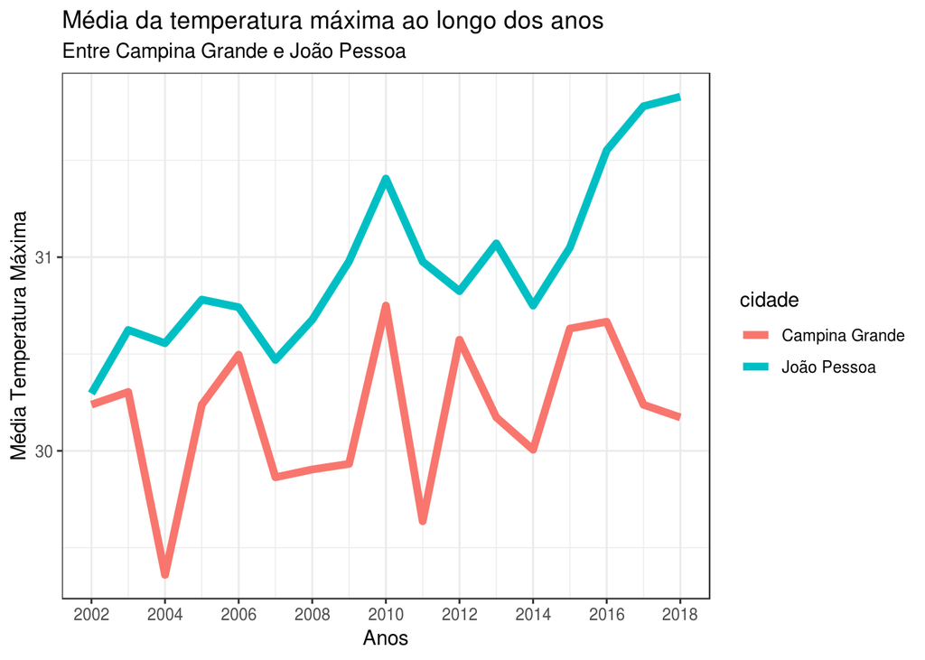

```r
media_por_ano = climas_qt %>%
                filter(ano > 2001 & ano < 2019)  %>%
                group_by(ano, cidade) %>%
                summarise(mean_tmax = mean(x=tmax), mean_tmedia = mean(x=tmedia), mean_chuva = mean(x=chuva))

g_mes = climas_qt %>% group_by(ano, mes, cidade) %>% summarise(mean_tmax = mean(x=tmax))

ggplot(data = media_por_ano, mapping = aes(x = ano, y = mean_tmax, label=mean_tmax)) +
                geom_line(aes(col=cidade), size=2) +
                ggtitle("Média da temperatura máxima ao longo dos anos", subtitle="Entre Campina Grande e João Pessoa") +
                xlab("Anos") +
                ylab("Média Temperatura Máxima") +
                scale_x_continuous(breaks = seq(2002,2018,2))
```

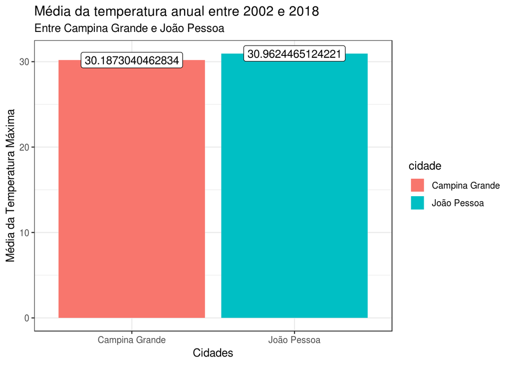

```r
media_por_cidade = media_por_ano %>%
                    group_by(cidade) %>%
                    summarise(mean_tmax = mean(x=mean_tmax), mean_tmedia = mean(x=mean_tmedia), mean_chuva = mean(x=mean_chuva))

ggplot(data = media_por_cidade, mapping = aes(x = cidade, y = mean_tmax, label=mean_tmax)) +
                geom_col(aes(fill=cidade), size=2) +
                ggtitle("Média da temperatura anual entre 2002 e 2018", subtitle="Entre Campina Grande e João Pessoa") +
                xlab("Cidades") +
                ylab("Média da Temperatura Máxima") +
                geom_label()
```

Calculando a média anual da temperatura máxima para cada cidade é possível visualizar o comportamento da temperatura ao longos dos anos. Observando essa primeira visualização é possível identificar como a temperatura de João Pessoa vem passando a temperatura de Campina Grande durante esse tempo. Uma vez que se considere a média de todos os anos chegamos aos valores da última visualização, sobre a qual podemos afirmar que João Pessoa apresenta a maior média e por isso pode ser considerada mais quente do que Campina Grande.

#### Quais os meses mais quentes e mais frios?

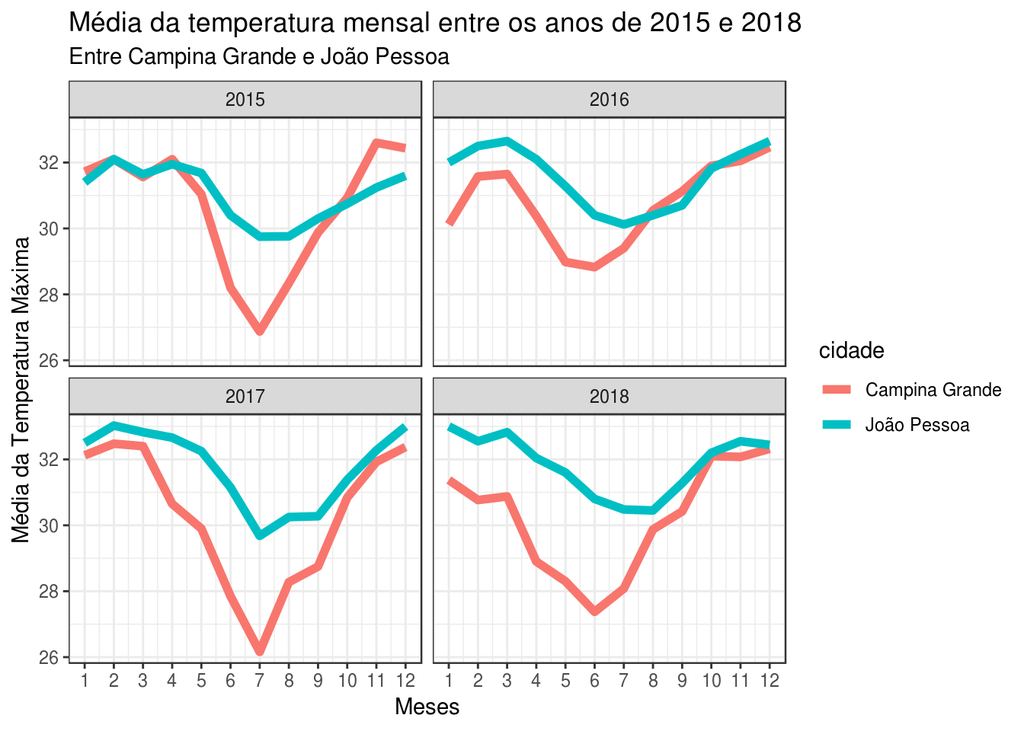

```r
media_por_mes_ano = climas_qt %>%
                filter(ano > 2001 & ano < 2019)  %>%
                group_by(ano, mes, cidade) %>%
                summarise(mean_tmax = mean(x=tmax), mean_tmedia = mean(x=tmedia), mean_chuva = mean(x=chuva))

media_por_mes_ano = media_por_mes_ano %>%
                filter(ano > 2014)

ggplot(data = media_por_mes_ano, mapping = aes(x = mes, y = mean_tmax)) +
                geom_line(aes(col=cidade), size=2) +
                ggtitle("Média da temperatura mensal entre os anos de 2015 e 2018",
                        subtitle="Entre Campina Grande e João Pessoa") +
                xlab("Meses") +
                ylab("Média da Temperatura Máxima") +
                facet_wrap(~ ano) +
                scale_x_continuous(breaks = seq(1,12,1))
```

Para observar o comportamento da temperatura ao longo dos anos entre 2015 e 2018 podemos observar o gráfico acima e ver que existem alguns padrões. Para Campina, por exemplo, geralmente o final do ano é o período de maior calor.

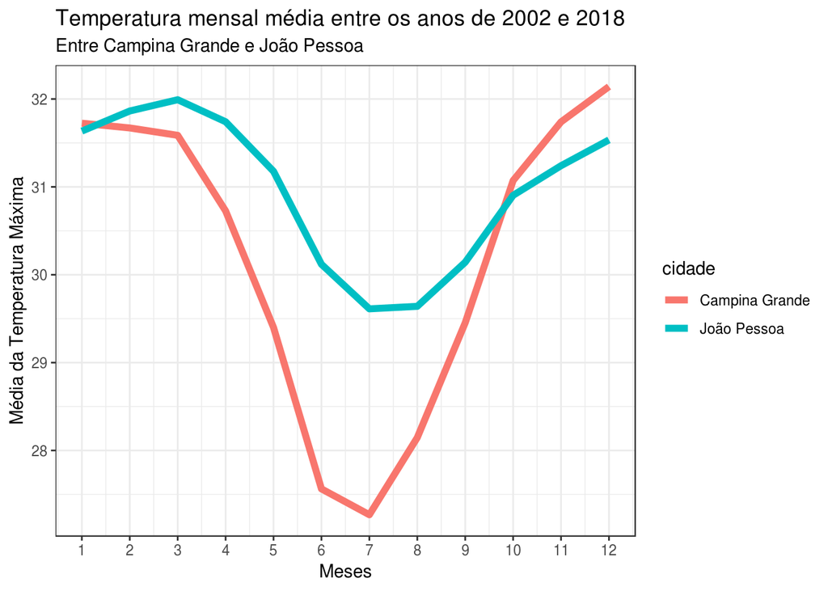

```r
media_por_mes_todos_os_anos = climas_qt %>%
                filter(ano > 2001 & ano < 2019)  %>%
                group_by(mes, cidade) %>%
                summarise(mean_tmax = mean(x=tmax), mean_tmedia = mean(x=tmedia), mean_chuva = mean(x=chuva))

ggplot(data = media_por_mes_todos_os_anos, mapping = aes(x = mes, y = mean_tmax)) +
                geom_line(aes(col=cidade), size=2) +
                ggtitle("Temperatura mensal média entre os anos de 2002 e 2018",
                        subtitle="Entre Campina Grande e João Pessoa") +
                xlab("Meses") +
                ylab("Média da Temperatura Máxima") +
                scale_x_continuous(breaks = seq(1,12,1))
```

Para chegar a uma resposta mais fechada observa-se a média de todos os anos entre 2002 e 2018 para cada mês, e nesse caso é possível identificar que os meses mais quentes são:

- **Março** para João Pessoa
- **Dezembro** para Campina Grande

E os meses mais frios - **Julho** para ambas as cidades

## Perguntas sobre Chuva

#### No geral, onde chove mais?

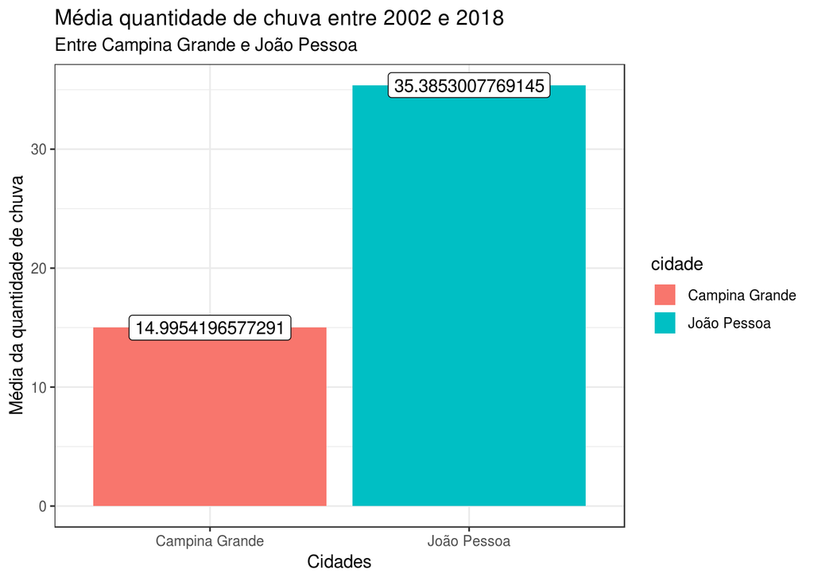

```r
ggplot(data = media_por_cidade, mapping = aes(x = cidade, y = mean_chuva, label=mean_chuva)) +
                geom_col(aes(fill=cidade), size=2) +
                ggtitle("Média quantidade de chuva entre 2002 e 2018", subtitle="Entre Campina Grande e João Pessoa") +
                xlab("Cidades") +
                ylab("Média da quantidade de chuva") +
                geom_label()
```

Considerando a média mensal e anual do índice pluviométrico de todos os anos da quantidade de chuva chegamos aos valores acima, sobre a qual podemos afirmar que chove mais em João Pessoa do que Campina Grande.

#### A distribuição é diferente em meses específicos?

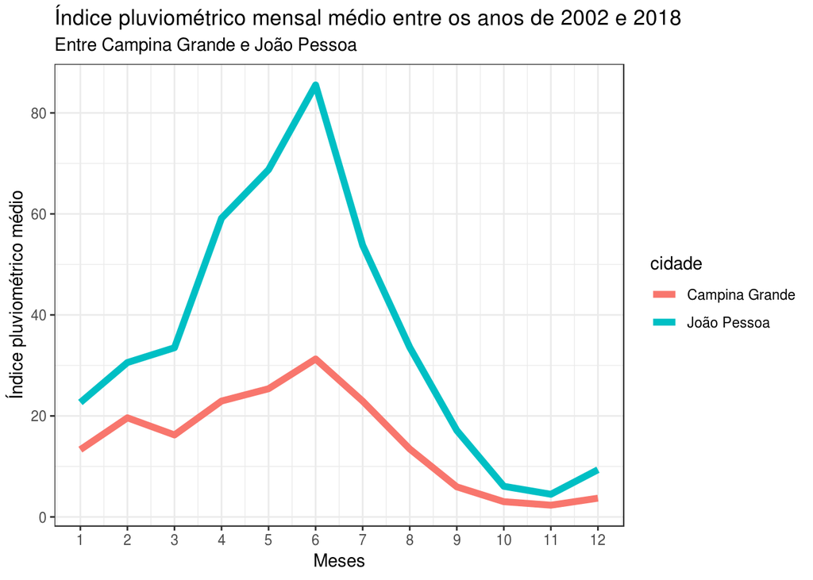

```r
ggplot(data = media_por_mes_todos_os_anos, mapping = aes(x = mes, y = mean_chuva)) +
                geom_line(aes(col=cidade), size=2) +
                ggtitle("Índice pluviométrico mensal médio entre os anos de 2002 e 2018",
                        subtitle="Entre Campina Grande e João Pessoa") +
                xlab("Meses") +
                ylab("Índice pluviométrico médio") +
                scale_x_continuous(breaks = seq(1,12,1))
```

Com a visualização acima pode-se observar que o mes com maior quantidade de chuva é **Junho** para ambas as cidades. E o mês com menos chuva é **Novembro**, também para ambas as cidades.